# Lab 2 - Permutation?

# Grading the Professor

Many college courses conclude by giving students the opportunity to evaluate the course and the instructor anonymously. However, the use of these student evaluations as an indicator of course quality and teaching effectiveness is often criticized because these measures may reflect the influence of non-teaching related characteristics, such as the physical appearance of the instructor. The article titled, “Beauty in the classroom: instructors’ pulchritude and putative pedagogical productivity” (Hamermesh and Parker, 2005) found that instructors who are viewed to be better looking receive higher instructional ratings. (Daniel S. Hamermesh, Amy Parker, Beauty in the classroom: instructors pulchritude and putative pedagogical productivity, Economics of Education Review, Volume 24, Issue 4, August 2005, Pages 369-376, ISSN 0272-7757, 10.1016/j.econedurev.2004.07.013. http://www.sciencedirect.com/science/article/pii/S0272775704001165.)

In this lab we will analyze the data from this study in order to learn what goes into a positive professor evaluation.

# Data for Today’s Lab

The data are gathered from end of semester student evaluations for a large sample of professors from the University of Texas at Austin. These data are merged with descriptors of the professors and the classes. In addition, six students rated the professors’ physical appearance. The result is a data frame where each row contains a different course and each column has information on either the course or the professor. [Data are available through the Open Intro Statitics course webpage](https://www.openintro.org/stat/data/evals.php).

This is a real dataset that has been used in a publication, *Looking Good on Course Evaluations*, published in 2013 in CHANCE volume 26 issue 2.

**1. Load the data into your work space and inspect it to answer the following questions:**

- **How many observations (rows) do the data have?**
- **How many variables (columns) do the data have?**
- **What class (data types) are the variables in the dataset?**

```r
# read_csv does not coerce strings to factors
evals <- read_csv("data/evals.csv")

glimpse(evals)
```

```
## Observations: 463
## Variables: 22
## $ X1            <dbl> 1, 2, 3, 4, 5, 6, 7, 8, 9, 10, 11, 12, 13, 14, 1...
## $ score         <dbl> 4.7, 4.1, 3.9, 4.8, 4.6, 4.3, 2.8, 4.1, 3.4, 4.5...
## $ rank          <chr> "tenure track", "tenure track", "tenure track", ...
## $ ethnicity     <chr> "minority", "minority", "minority", "minority", ...
## $ gender        <chr> "female", "female", "female", "female", "male", ...
## $ language      <chr> "english", "english", "english", "english", "eng...
## $ age           <dbl> 36, 36, 36, 36, 59, 59, 59, 51, 51, 40, 40, 40, ...
## $ cls_perc_eval <dbl> 55.81395, 68.80000, 60.80000, 62.60163, 85.00000...
## $ cls_did_eval  <dbl> 24, 86, 76, 77, 17, 35, 39, 55, 111, 40, 24, 24,...
## $ cls_students  <dbl> 43, 125, 125, 123, 20, 40, 44, 55, 195, 46, 27, ...
## $ cls_level     <chr> "upper", "upper", "upper", "upper", "upper", "up...
## $ cls_profs     <chr> "single", "single", "single", "single", "multipl...
## $ cls_credits   <chr> "multi credit", "multi credit", "multi credit", ...
## $ bty_f1lower   <dbl> 5, 5, 5, 5, 4, 4, 4, 5, 5, 2, 2, 2, 2, 2, 2, 2, ...
## $ bty_f1upper   <dbl> 7, 7, 7, 7, 4, 4, 4, 2, 2, 5, 5, 5, 5, 5, 5, 5, ...
## $ bty_f2upper   <dbl> 6, 6, 6, 6, 2, 2, 2, 5, 5, 4, 4, 4, 4, 4, 4, 4, ...
## $ bty_m1lower   <dbl> 2, 2, 2, 2, 2, 2, 2, 2, 2, 3, 3, 3, 3, 3, 3, 3, ...
## $ bty_m1upper   <dbl> 4, 4, 4, 4, 3, 3, 3, 3, 3, 3, 3, 3, 3, 3, 3, 3, ...
## $ bty_m2upper   <dbl> 6, 6, 6, 6, 3, 3, 3, 3, 3, 2, 2, 2, 2, 2, 2, 2, ...
## $ bty_avg       <dbl> 5.000, 5.000, 5.000, 5.000, 3.000, 3.000, 3.000,...
## $ pic_outfit    <chr> "not formal", "not formal", "not formal", "not f...
## $ pic_color     <chr> "color", "color", "color", "color", "color", "co...
```

**2. Is this an observational study or an experiment? The original research question posed in the paper is whether being a man leads directly to the differences in course evaluations.** **(a) Given the study design, is it possible to answer this question as it is phrased?**

**(b) If not, rephrase the research question that can be addressed.**

## Cleaning the Data

Unfortunately, the individuals responsible for recording the data incorrectly labeled the variable `gender`. Run the code below to change the name of this variable to its correct label of `sex`.

```r
# data cleaning
evals <- evals %>%
          rename(sex = gender) # renames the gender variable to sex
```

**Bonus: What issues could arise with data labeled in this way? How would these options for gender impact the study participants or people reading the article’s results?**

# Plotting the Data

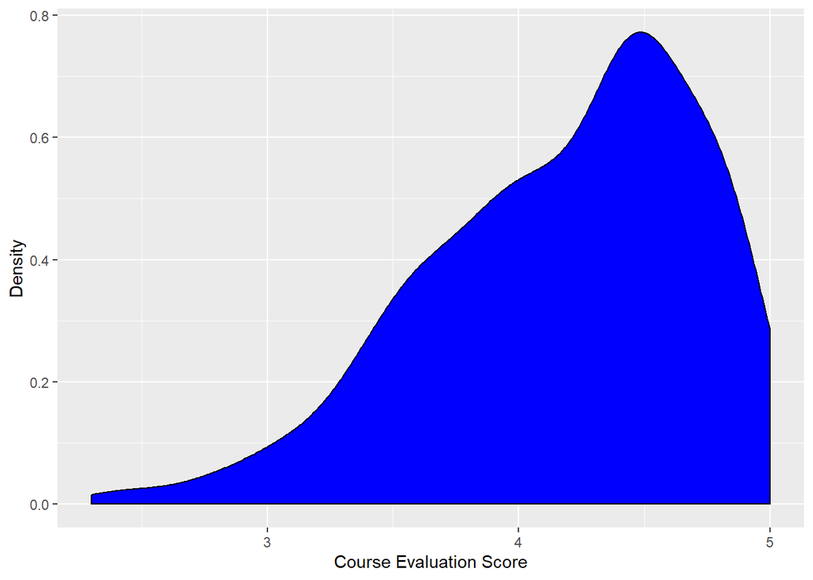

```r
ggplot(data = evals, mapping = aes(x = score)) +
  geom_density(fill = "blue") +
  labs(
    x = "Course Evaluation Score",
    y = "Density"
  )
```

**3. Describe the distribution of `score`. Is the distribution skewed? What does this tell you about how students rate courses? Is this what you expected to see? Why, or why not?**

Next, let’s compare the course evaluation scores and average beauty scores of the two sexes of professors.

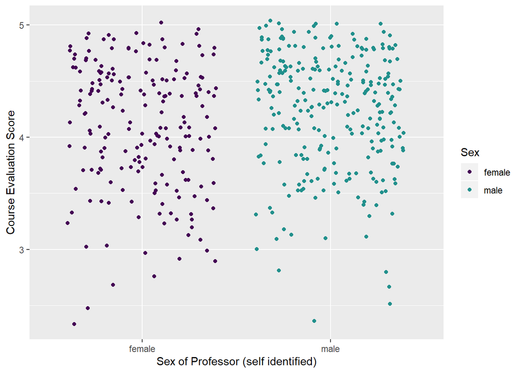

```r
# Side-by-side dot plot
ggplot(data = evals, mapping = aes(x = sex, y = score)) +
  # defines what variables are mapped to different attributes of the plot

  geom_jitter(aes(color = sex)) +
  # tells R to plot jittered dots and color them by sex

  scale_color_manual(values = viridis(n = 3)) +
  # a nicer color palette than the default

  labs(
    y = "Course Evaluation Score", # y-axis label
    x = "Sex of Professor (self identified)", # x-axis label
    color = "Sex" # color label
  )
```

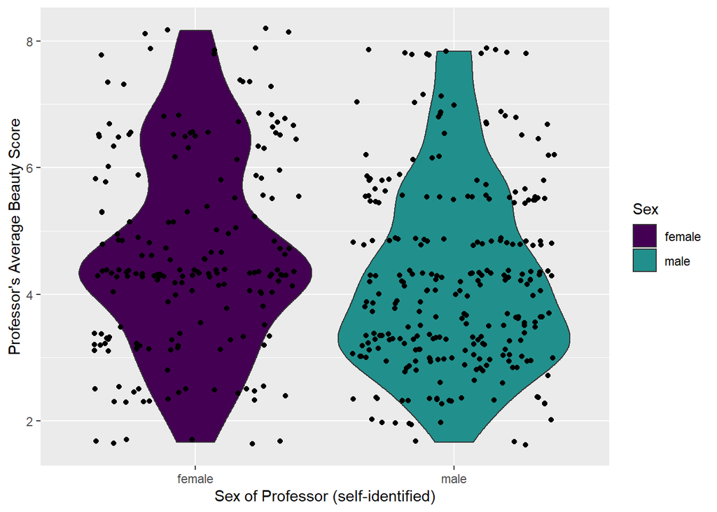

```r
# side-by-side violin plots
ggplot(data = evals, mapping = aes(x = sex, y = bty_avg)) +
  # defines what variables are mapped to different attributes of the plot

  geom_violin(aes(fill = sex)) +
  # tells R to plot violins of the density of the points for each sex

  geom_jitter() +
  # tells R to plot jittered dots on top of the violins

  scale_fill_manual(values = viridis(n = 3)) +
  # a nicer color palette than the default

  labs(
    y = "Professor's Average Beauty Score", # y-axis label
    x = "Sex of Professor (self-identified)", # x-axis label
    fill = "Sex" # color label
  )
```

**4. Based on the plots above what can you say about the course evaluation scores and average beauty scores for professors who identified as male verses those who identified as female?**